# ゲームハード週販レポート (2025.10.26)

国内ゲームハード週販レポート (2025-10-26)

- ハードウェアの販売データはファミ通の調査結果を基にしています。
- 一部のデータは処理上の都合により、週次値に調整しています。
- 過去の週販レポート

## 直近4週間のハード売り上げ／累計推移

Switch2の販売台数は先週の20万台に比べ6万5千台と一気に下降しました。 相当にメリハリの効いたスパイク的な出荷を行なっているようです。転売対策には有効な施策ですが小売は大変だと思います。 この後、Switch2に控えている主なタイトルとしては以下がありますが、 Switch2の大量出荷が期待できるとすれば11/20のエアライダーでしょうか。ゼルダ無双でも若干増えるかも。 メトロイドで大量出荷は無いと思われます。

- ゼルダ無双 11/6
- 桃太郎電鉄 11/13
- エアライダー 11/20
- メトロイドプライム4 ビヨンド 12/4

大量出荷を行う週以外は、平均7万程度で推移するのか、クリスマスシーズンに向けて 徐々に出荷を増やして10万超/週になるのか、今後の注目点です。

Switchは超安定。よくわかりませんが若干増えています。 Switch2には無いLITEが売れてるのかと思うと、そうではなく、お高いOLED版が今週も1万6千台売れてます。

PS5はAUTUMN SALE期間ではありますが、売り上げが減少しています。 頻繁なセールで効果が落ちています。

| 集計日 | ハード | 販売台数 | 累計台数 |
| --- | --- | --- | --- |
| 2025-10-05 | Nintendo Switch2 | 44,439 | 2,154,061 |
|  | PlayStation5 | 27,344 | 7,084,279 |
|  | Nintendo Switch | 24,109 | 36,052,553 |
|  | Xbox Series X\|S | 837 | 685,352 |
|  | PlayStation4 | 19 | 9,490,853 |
| 2025-10-12 | Nintendo Switch2 | 46,842 | 2,200,903 |
|  | Nintendo Switch | 23,149 | 36,075,702 |
|  | PlayStation5 | 14,800 | 7,099,079 |
|  | Xbox Series X\|S | 237 | 685,589 |
|  | PlayStation4 | 17 | 9,490,870 |
| 2025-10-19 | Nintendo Switch2 | 201,684 | 2,402,587 |
|  | Nintendo Switch | 23,713 | 36,099,415 |
|  | PlayStation5 | 12,085 | 7,111,164 |
|  | Xbox Series X\|S | 188 | 685,777 |
|  | PlayStation4 | 23 | 9,490,893 |
| 2025-10-26 | Nintendo Switch2 | 65,434 | 2,468,021 |
|  | Nintendo Switch | 25,109 | 36,124,524 |
|  | PlayStation5 | 10,503 | 7,121,667 |
|  | Xbox Series X\|S | 991 | 686,768 |
|  | PlayStation4 | 15 | 9,490,908 |

## 2025年の週販推移

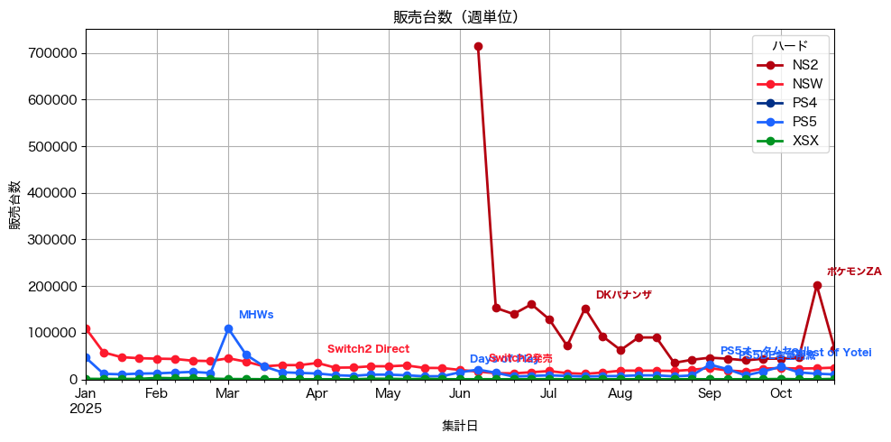

### 2025年の週販推移(拡大）

急峻なZAの山が出来ました。 Switch2の出荷にメリハリがありすぎて、今後どうなるのかはわかりません。

PS5については、セール効果の無くなる次週、1万台を切ると思われます。

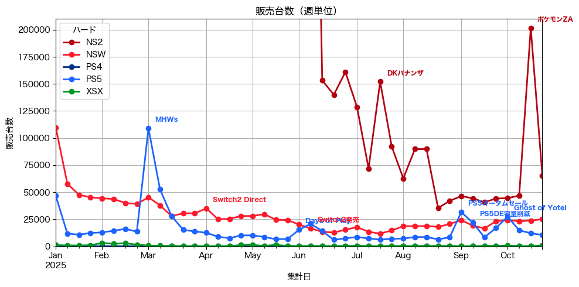

## 20年間の状況(ソニー編)

2025年の週販も残り9回。年末商戦を前に「2025年の位置付け」を20年間のハード売り上げで振り返ってみます。 今週はソニー編です。（任天堂は来週やります）

以下は2005年から2025年10月までの各年のハード売り上げ台数です。 複数の機種がある場合は積み上げてます。

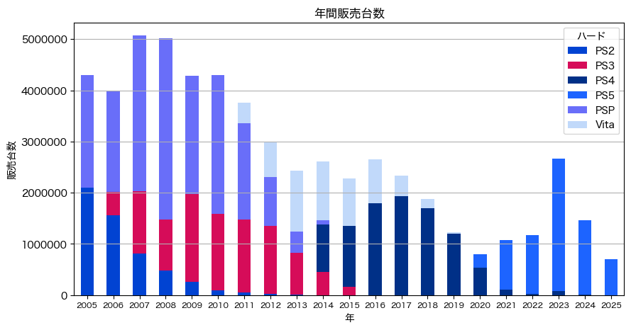

ハード売り上げのピークが2007,2008年にあり、全体としては右肩下がりの傾向です。 これは実は任天堂も同様の傾向です。理由は **iPhone3Gが2008年に発売された** からです。 「Before iPhone」と「After iPhone」は違う時代と捉える必要があります。

2023年のPS5はPSにとって画期的だったことがわかります。 ほぼ単機種で2016年のPS4+Vitaに匹敵する売り上げを達成しています。 このまま行けば日本のPS復活が期待されましたが、 ここから急ブレーキがかかります。 **2025年のPS5はPSの正念場**です。

### 2024年の年間145万台を超えられるか

2024年のPS5 年間販売台数は145万台。これを超えるには残り2ヶ月で80万台の販売が必要ですが、 これは明らかに不可能です。

### 年間100万台を超えられるか

年間100万台を下回ったのは、過去に2020年だけです。 今年中に100万台に到達するには、あと31万台の販売が必要です。 週平均3.4万台ですから、これもほぼ不可能でしょう。

### 2020年の最低記録を超えられるか

PS販売の年間最低記録は2020年の79万台です。 この年はPS4からPS5への世代交代年でしたが、PS5の出荷台数が少なくロンチの効果がありませんでした。 今年の現時点でのPS5+PS4の販売台数は69万台です。 最低記録を回避するにはあと10万台必要です。 **11月、12月であと10万台** 販売するのは何としても達成したいところでしょう。

平時のPS5の1万台/週では達成できません。 強力なセールが必要です。1万円引きでは足りないかもしれません。しかし、不可能な数字ではありません。

というわけで、残り2ヶ月のPS5は **最低記録更新阻止** に向けた商戦となります。

## 2025年の月間販売推移

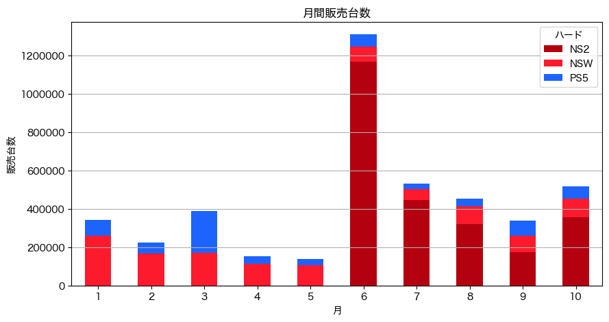

Switch2の10月販売台数はZAの影響で9月を大きく上回りました。 Switchも9月を上回ってます。 PS5はビッグタイトル Ghost of Yotei がありましたが、10月の月間販売数が9月を下回りました。

| hw month | NS2 | NSW | PS5 |
| --- | --- | --- | --- |
| 1 | 0 | 260,447 | 81,587 |
| 2 | 0 | 167,188 | 56,886 |
| 3 | 0 | 171,921 | 218,300 |
| 4 | 0 | 113,513 | 38,983 |
| 5 | 0 | 106,506 | 32,001 |
| 6 | 1,169,684 | 78,097 | 63,516 |
| 7 | 444,706 | 57,532 | 28,959 |
| 8 | 319,690 | 94,517 | 39,004 |
| 9 | 175,542 | 82,946 | 78,693 |
| 10 | 358,399 | 96,080 | 64,732 |

### Nintendo Switchの月間販売台数： 2023,2024年との比較

Switch2大量出荷にも関わらずSwitchの販売台数は安定しています。 9月の前年比26.9%に比べ、10月の前年比は39.14%に留まり若干改善しました。

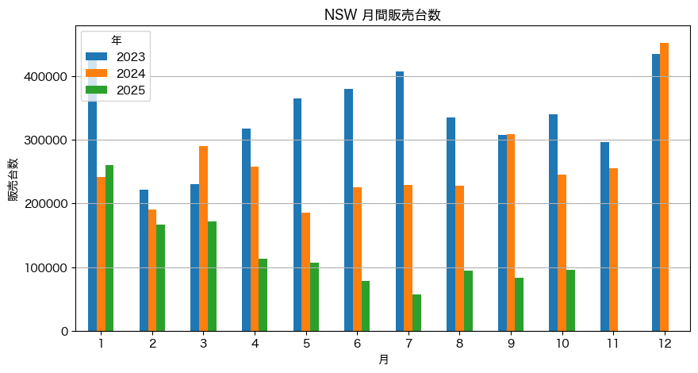

### PlayStation 5の月間販売台数： 2023, 2024年との比較

2025年10月のPS5は前年の10月を超えました。9月に続き2ヶ月連続で前年超えです。 しかし、昨年の11月は15万台、12月は16万台という高い売上台数を記録しています。 これを超えるのは並大抵ではありません。2025年の11月、12月は前年比で減少すると思われます。

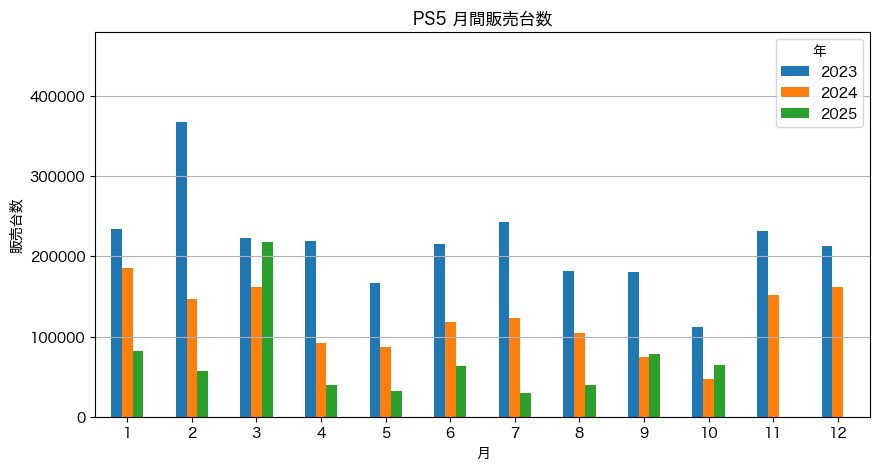

## 累計販売推移

Switch2 20万台の大量出荷がありましたが、累計グラフの見た目の変化はまだ大きくありません（右端が気持ち上がったかな程度）。 今後のSwitch2 年末商戦で変化があるでしょう。

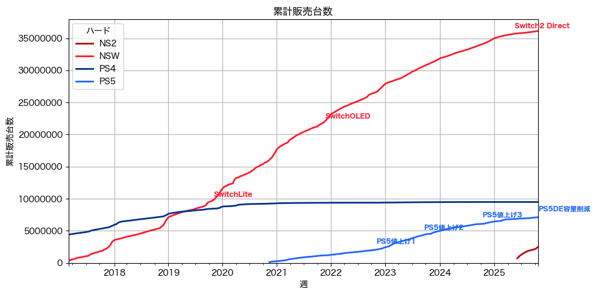

## Switch2販売状況

### 歴代機種との比較

ZA発売週の20万台がグラフの傾きにハッキリと現れています。 今後、初動歴代2位から3位に落ちる可能性はなさそうですが、 今のペースで歴代1位を超えるのは困難でしょう。

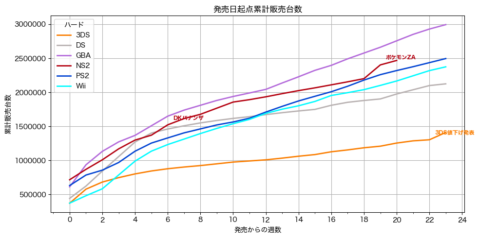

| ハード | 週数 | 販売数 |
| --- | --- | --- |
| GBA | 20 | 2,756,318 |
| NS2 | 20 | 2,468,021 |
| PS2 | 20 | 2,319,488 |
| Wii | 20 | 2,166,405 |
| DS | 20 | 1,975,309 |
| 3DS | 20 | 1,254,604 |

### 累計300万到達の見込み

今年の集計もあと9回。この先、年末まで平均7万/週で行けるなら、今年中に累計310万台に到達します。 過去機種で300万到達の時期を見てみると、最短はGAME BOY ADVANCEです。 Switch2はこれと1ヶ月差での300万台到達になると見込まれます。

| ハード | 達成年週 | 週数 | 累計販売数 |
| --- | --- | --- | --- |
| GAME BOY ADVANCE | 2001-09-09 | 24 | 3051291 |
| Wii | 2007-07-15 | 32 | 3014828 |
| Nintendo 3DS | 2011-12-11 | 41 | 3233571 |
| Nintendo DS | 2005-09-18 | 41 | 3015412 |
| PlayStation2 | 2000-12-17 | 41 | 3005742 |
| Nintendo Switch | 2017-12-24 | 42 | 3291903 |
| PocketStation | 2000-01-23 | 52 | 3011335 |
| PlayStation Portable | 2006-02-26 | 63 | 3021494 |
| Nintendo GAMECUBE | 2004-01-04 | 120 | 3115532 |
| PlayStation5 | 2023-03-05 | 120 | 3057112 |

## Switch/Switch2ロンチ比較

#### Switch2のスパイク状出荷

先週の20万台から6万5千台に急降下です。DKバナンザの時と同様にビッグタイトル発売週に集中的に出荷しています。 今後、夏のように5万弱で推移するのか、年末商戦らしい10万台水準に上がっていくのか注目です。

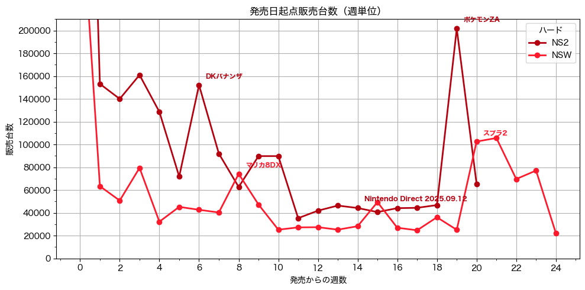

## 年単位の状況

全機種合わせた年毎のハード販売の状況です。 2025年は2ヶ月を残して440万台です。2024年の457万台を超えるのは確実です。 500万台は到達可能ですが、600万台は難しいでしょう。

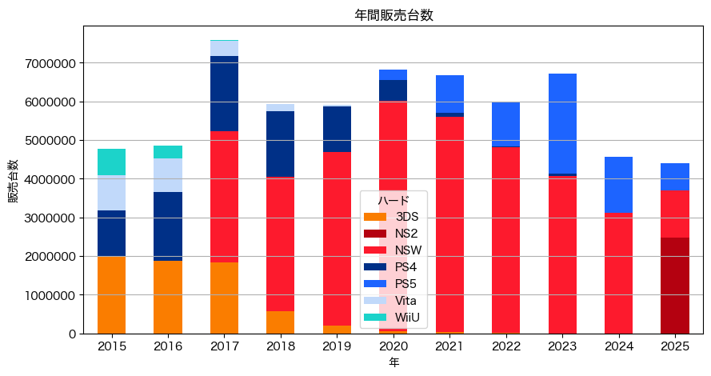